# MP_SRF_amplicons_fraction_18_and_16S_diversity_analysis

lrubinat

05/05/2016

# 1) 18S amplicons

## 1.1) Data overview

Let’s read the dataset and remove the samples containing less than 11770 reads:

```
## [1] 22702    18
```

```
##   OTUId st019 st030 st044 st063
## 1 OTU_1  5572     0   526  1030
## 2 OTU_2  2856  7249   656   544
## 3 OTU_3 12685   234     5   143
## 4 OTU_4 20486   109     0     2
## 5 OTU_5  1124     0  1353   149
```

```
## [1] 22702    17
```

```
##       st019 st030 st044 st063 st076
## OTU_1  5572     0   526  1030  2624
## OTU_2  2856  7249   656   544  4199
## OTU_3 12685   234     5   143   792
## OTU_4 20486   109     0     2     2
## OTU_5  1124     0  1353   149  1499
```

```
## [1] 22702     7
```

```
##                                                                                             SILVA_taxonomic_classification
## OTU_1           EF172947.1.1553_Eukaryota;SAR;Alveolata;Protalveolata;Syndiniales;Syndiniales_Group_I;uncultured_eukaryote
## OTU_2 FJ832119.1.1585_Eukaryota;SAR;Alveolata;Protalveolata;Syndiniales;Syndiniales_Group_I;uncultured_marine_picoplankton
## OTU_3          EU780613.1.1717_Eukaryota;SAR;Alveolata;Protalveolata;Syndiniales;Syndiniales_Group_II;uncultured_eukaryote
## OTU_4                             AY520446.1.1695_Eukaryota;SAR;Stramenopiles;Bicosoecida;Caecitellus;Caecitellus_parvulus
## OTU_5          EU780594.1.1712_Eukaryota;SAR;Alveolata;Protalveolata;Syndiniales;Syndiniales_Group_II;uncultured_eukaryote
##             MAS_taxonomic_classification       BM_taxonomic_classification
## OTU_1          GQ913047_MALV-I_Alveolata         32_MALV-I_Alveolata_15673
## OTU_2          EU793773_MALV-I_Alveolata         3261_MALV-I_Alveolata_385
## OTU_3         FJ537505_MALV-II_Alveolata         173_MALV-II_Alveolata_516
## OTU_4 EF620527_Bicosoecids_Stramenopiles 2638_Bicosoecida_Stramenopiles_17
## OTU_5         EU793869_MALV-II_Alveolata        2230_MALV-II_Alveolata_177
##       SILVA_class MAS_class BM_class MAS_plus_BM_plus_SILVA_class
## OTU_1        <NA>      <NA>     <NA>                         <NA>
## OTU_2        <NA>      <NA>     <NA>                         <NA>
## OTU_3        <NA>      <NA>     <NA>                         <NA>
## OTU_4        <NA>      <NA>     <NA>                         <NA>
## OTU_5        <NA>      <NA>     <NA>                         <NA>
```

```
## [1] 22702    10
```

```
##       st019 st030 st044 st063 st076 st083 st092 st101 st120 st141
## OTU_1  5572     0   526  1030  2624   167 10607  2087 32356 12125
## OTU_2  2856  7249   656   544  4199   212  2694  1948 28186  2185
## OTU_3 12685   234     5   143   792   289  1014  4135   540  4017
## OTU_4 20486   109     0     2     2     0     1     0     0     0
## OTU_5  1124     0  1353   149  1499   172  9432   701  1322  2349
```

```
## named numeric(0)
```

```
## [1] 22702    10
```

```
## [1] 22702     9
```

```
## [1] 22702     0
```

Table dimensions and content outline:

```
## [1] 22702     9
```

```
##       st019 st044 st063 st076 st083
## OTU_1  5572   526  1030  2624   167
## OTU_2  2856   656   544  4199   212
## OTU_3 12685     5   143   792   289
## OTU_4 20486     0     2     2     0
## OTU_5  1124  1353   149  1499   172
```

Minimum number of reads per station:

```r
min(colSums(tb18_tax_occur_min11770))
```

```
## [1] 11770
```

Maximum number of reads per station:

```r
max(colSums(tb18_tax_occur_min11770))
```

```
## [1] 275821
```

Identification of station with higher number of reads:

```r
amplicons_per_sample<-colSums(tb18_tax_occur_min11770)
amplicons_per_sample[which(colSums(tb18_tax_occur_min11770)>275820)]
```

```
##  st019
## 275821
```

Overall reads per sample:

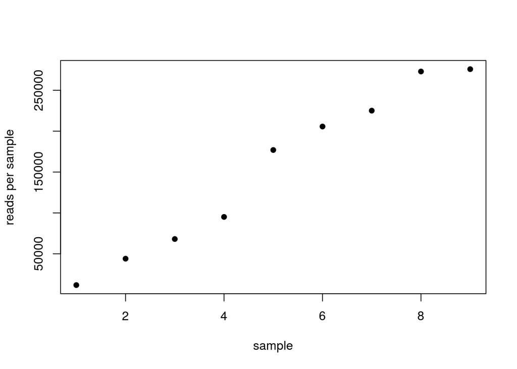

## 1.2) Normalization

Let’s normalize the original dataset by randomly subsampling 11770 reads in each station:

```r
library(vegan)
tb18_tax_occur_min11770_t<-t(tb18_tax_occur_min11770)
tb18_tax_occur_ss11770<-rrarefy(tb18_tax_occur_min11770_t, 11770)
```

The normalized table shows the following dimensions and format:

```
## [1]     9 22702
```

```
##       OTU_1 OTU_2 OTU_3 OTU_4 OTU_5
## st019   228   112   499   880    45
## st044    84   107     1     0   246
## st063   274   155    37     2    45
## st076   156   278    54     1   112
## st083   167   212   289     0   172
```

Its content fits with the expected normalization values (11770 reads per station):

```r
rowSums(tb18_tax_occur_ss11770)
```

```
## st019 st044 st063 st076 st083 st092 st101 st120 st141
## 11770 11770 11770 11770 11770 11770 11770 11770 11770
```

Let’s check out how many OTUs don’t appear in the new table:

```r
length(which(colSums(tb18_tax_occur_ss11770)==0))
```

```
## [1] 13759
```

```r
tb18_tax_occur_ss11770_no_cero<-tb18_tax_occur_ss11770[,-(which(colSums(tb18_tax_occur_ss11770)==0))]
dim(tb18_tax_occur_ss11770_no_cero)
```

```
## [1]    9 8943
```

## 1.3) Taxonomic composition analysis

### 1.3.1) Normalized data

#### 1.3.1.1) Absolute values

Let’s add the taxonomic classification to the left OTUs by merging “tb18_tax_occur_ss11770_no_cero” with “tb18_tax”:

```
## [1] 8943   17
```

```
##   Row.names st019 st044 st063 st076
## 1     OTU_1   228    84   274   156
## 2    OTU_10   133    28    91     7
## 3   OTU_100     7     0    14    91
## 4  OTU_1000     2     0     0     0
## 5 OTU_10004     0     0     1     0
```

```
## [1] 8943   16
```

```
##           st019 st044 st063 st076 st083
## OTU_1       228    84   274   156   167
## OTU_10      133    28    91     7   205
## OTU_100       7     0    14    91    24
## OTU_1000      2     0     0     0     0
## OTU_10004     0     0     1     0     0
```

```
## [1] 8943   17
```

```
##       st019 st044 st063 st076 st083
## OTU_1   228    84   274   156   167
## OTU_2   112   107   155   278   212
## OTU_3   499     1    37    54   289
## OTU_4   880     0     2     1     0
## OTU_5    45   246    45   112   172
```

```
## [1] 2154   17
```

```
##        st019 st044 st063 st076 st083
## OTU_10   133    28    91     7   205
## OTU_12    80    71    83   102    48
## OTU_17    50    28   190    40   150
## OTU_24    44    11    16    20    53
## OTU_49    23     6    50    37    24
```

```
##        st019 st044 st063 st076 st083
## OTU_10   133    28    91     7   205
## OTU_12    80    71    83   102    48
## OTU_17    50    28   190    40   150
## OTU_24    44    11    16    20    53
## OTU_49    23     6    50    37    24
```

```
## [1] 1774    9
```

```
## [1] 9
```

```
## [1] 9
```

```
## [1] 9
```

```
## [1] 9
```

```
## [1] 9
```

```
## [1] 7
```

```
## [1] 7
```

```
## [1] 9
```

```
## [1] 8
```

```
## [1] 7
```

```
## [1] 7
```

```
## [1] 3
```

```
## [1] 2
```

```
## [1] 1
```

```
## [1] 2
```

```
## [1] 4
```

```
## [1] 0
```

```
##               Group.1     x
## 8         Dinophyceae 12154
## 13     Prasinophyceae  1617
## 11      Pelagophyceae  1520
## 5       Chrysophyceae  1113
## 7    Dictyochophyceae   621
## 6     Cryptomonadales   247
## 1     Bacillariophyta    76
## 3  Chlorarachniophyta    71
## 2       Bolidophyceae    66
## 12  Pinguiochysidales    18
## 14   Prymnesiophyceae    18
## 10    Mamiellophyceae    13
## 9       Eustigmatales     9
## 15     Raphydophyceae     7
## 16        Ulvophyceae     2
## 4       Chlorophyceae     1
```

```
##               Group.1    x
## 8         Dinophyceae 1774
## 13     Prasinophyceae   93
## 5       Chrysophyceae   76
## 11      Pelagophyceae   72
## 7    Dictyochophyceae   61
## 1     Bacillariophyta   15
## 3  Chlorarachniophyta   15
## 6     Cryptomonadales   14
## 10    Mamiellophyceae    7
## 12  Pinguiochysidales    7
## 14   Prymnesiophyceae    7
## 2       Bolidophyceae    5
## 9       Eustigmatales    3
## 15     Raphydophyceae    2
## 16        Ulvophyceae    2
## 4       Chlorophyceae    1
```

```
##                    reads_per_class OTUs_per_class
## Bacillariophyta                 76             15
## Bolidophyceae                   66              5
## Chlorarachniophyta              71             15
## Chlorophyceae                    1              1
## Chrysophyceae                 1113             76
```

```
##                    reads_per_class OTUs_per_class samples_per_class
## Dinophyceae                  12154           1774                 9
## Prasinophyceae                1617             93                 9
## Pelagophyceae                 1520             72                 9
## Chrysophyceae                 1113             76                 9
## Dictyochophyceae               621             61                 9
## Cryptomonadales                247             14                 7
## Bacillariophyta                 76             15                 7
## Chlorarachniophyta              71             15                 9
## Bolidophyceae                   66              5                 8
## Pinguiochysidales               18              7                 7
## Prymnesiophyceae                18              7                 7
## Mamiellophyceae                 13              7                 3
## Eustigmatales                    9              3                 2
## Raphydophyceae                   7              2                 4
## Ulvophyceae                      2              2                 2
## Chlorophyceae                    1              1                 1
```

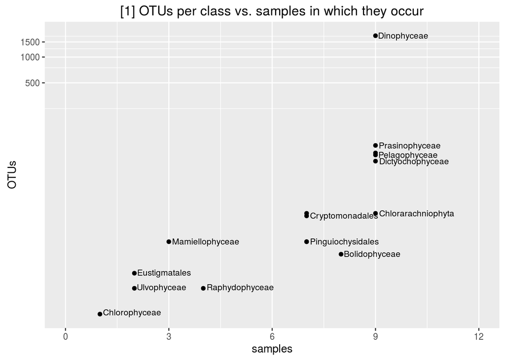

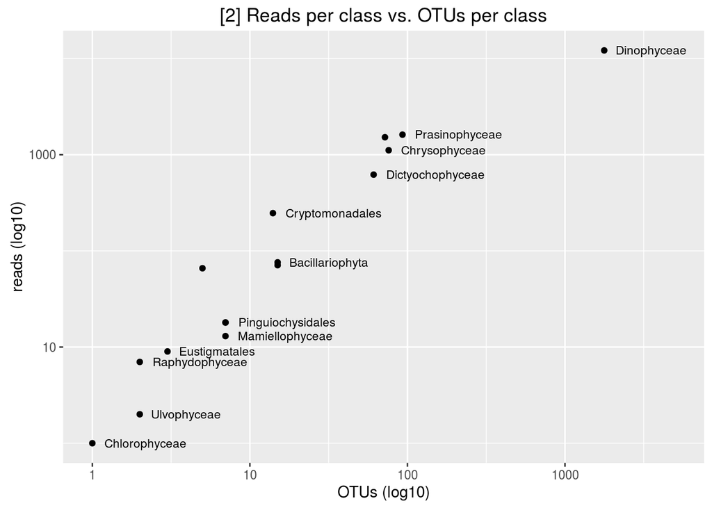

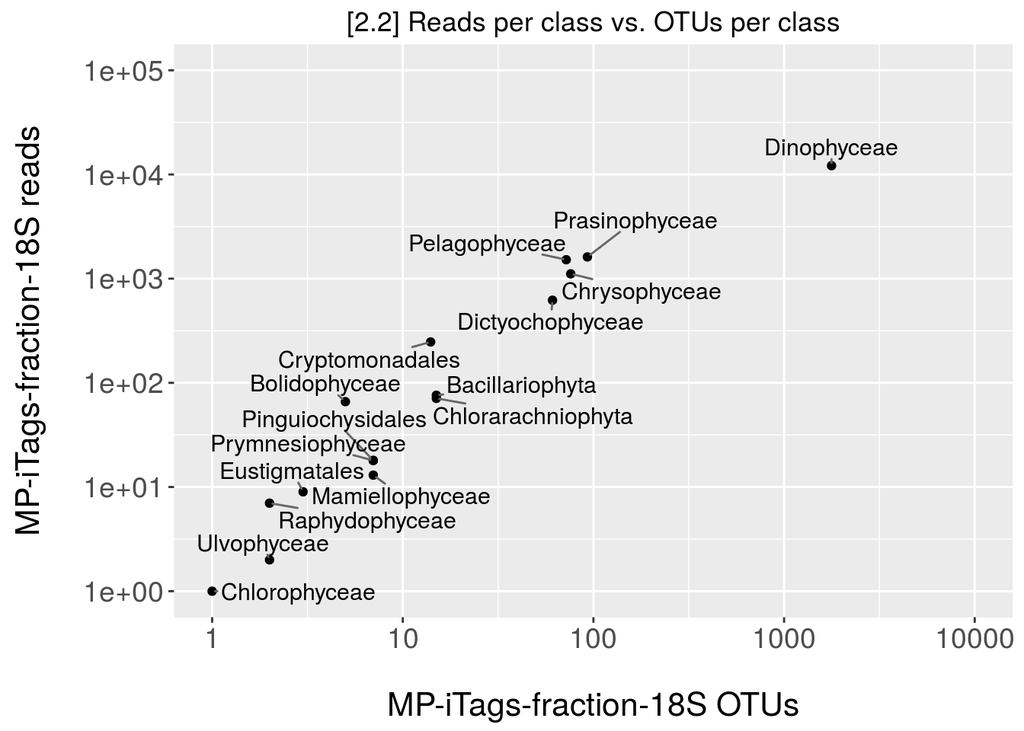

#### 1.3.1.1) Relative values

```
##   reads_per_class    OTUs_per_class samples_per_class
##           100.000           100.000          1133.333
```

```
##                    reads_per_class OTUs_per_class samples_per_class
## Dinophyceae           69.241725061    82.35840297         100.00000
## Prasinophyceae         9.212100496     4.31754875         100.00000
## Pelagophyceae          8.659488407     3.34261838         100.00000
## Chrysophyceae          6.340796445     3.52831941         100.00000
## Dictyochophyceae       3.537856777     2.83194058         100.00000
## Cryptomonadales        1.407166866     0.64995357          77.77778
## Bacillariophyta        0.432974420     0.69637883          77.77778
## Chlorarachniophyta     0.404489261     0.69637883         100.00000
## Bolidophyceae          0.376004102     0.23212628          88.88889
## Pinguiochysidales      0.102546573     0.32497679          77.77778
## Prymnesiophyceae       0.102546573     0.32497679          77.77778
## Mamiellophyceae        0.074061414     0.32497679          33.33333
## Eustigmatales          0.051273287     0.13927577          22.22222
## Raphydophyceae         0.039879223     0.09285051          44.44444
## Ulvophyceae            0.011394064     0.09285051          22.22222
## Chlorophyceae          0.005697032     0.04642526          11.11111
```

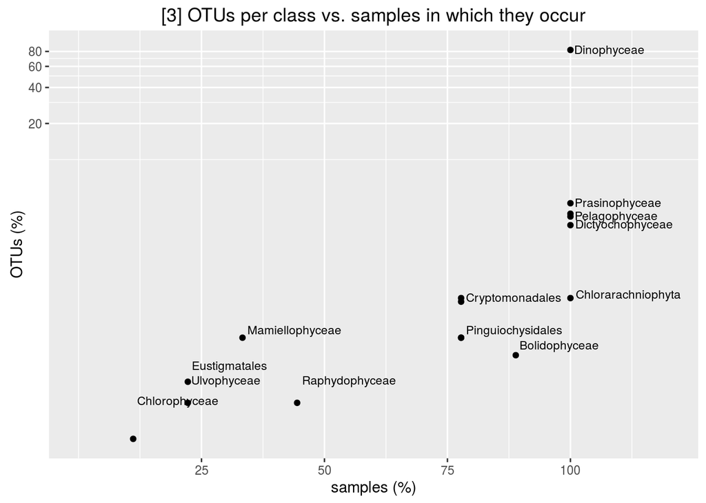

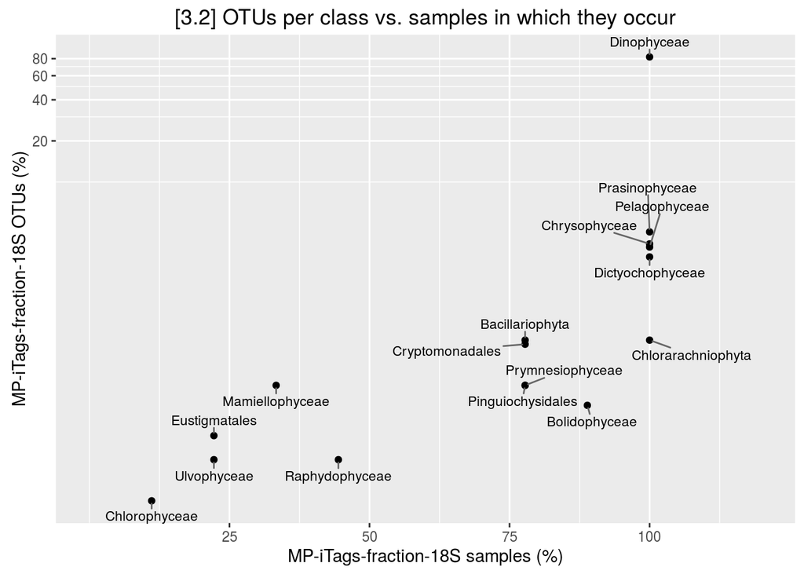

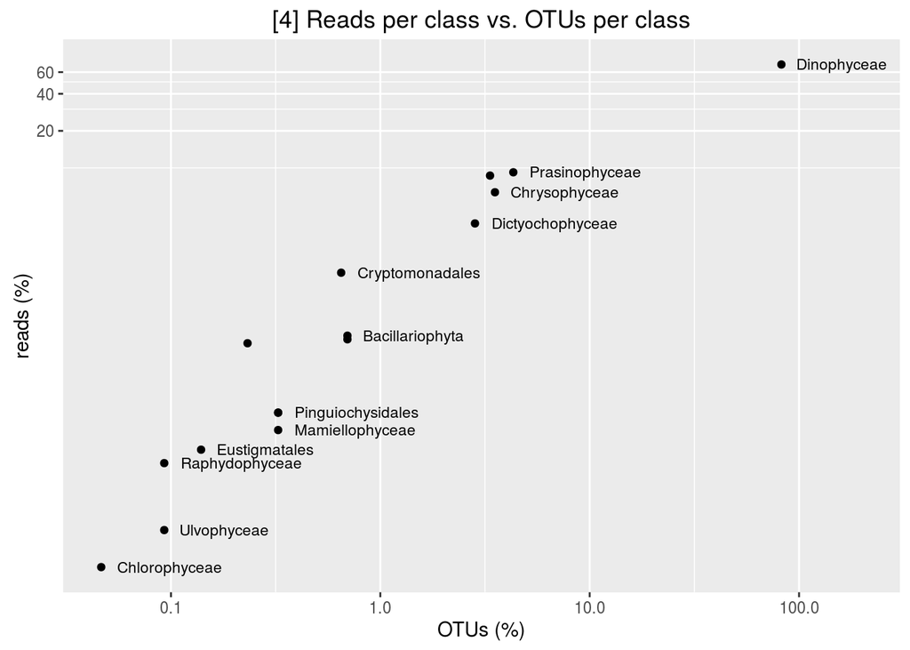

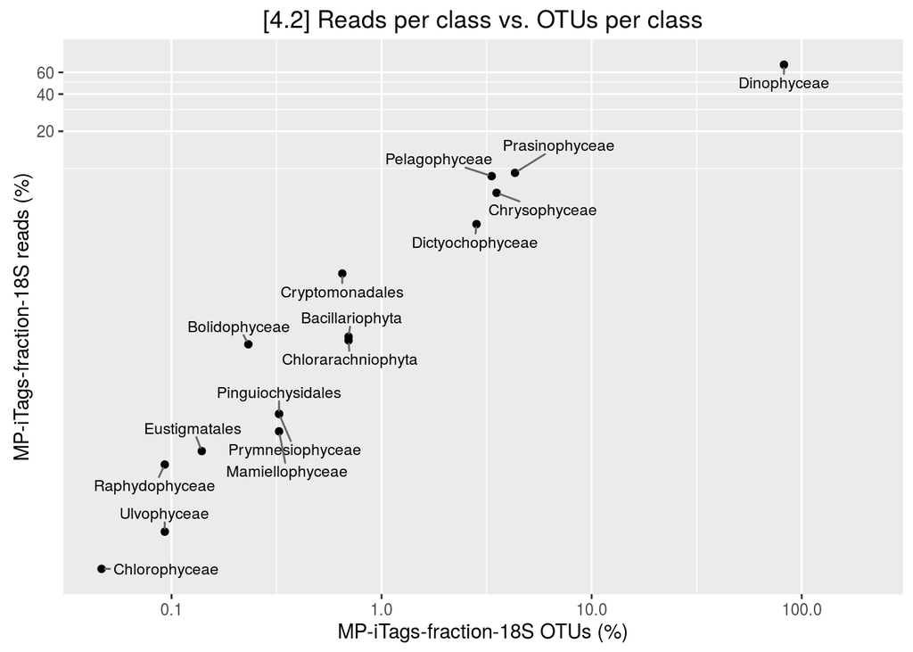

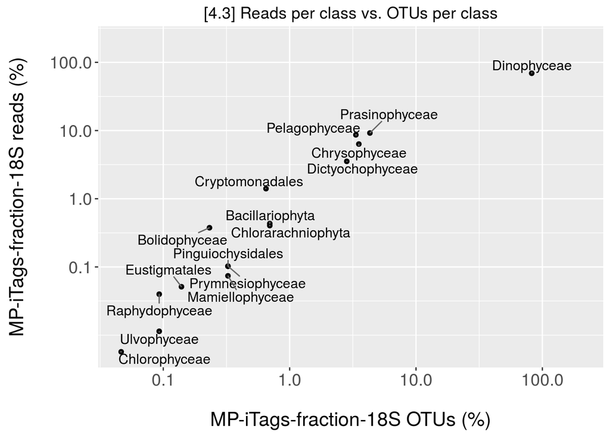

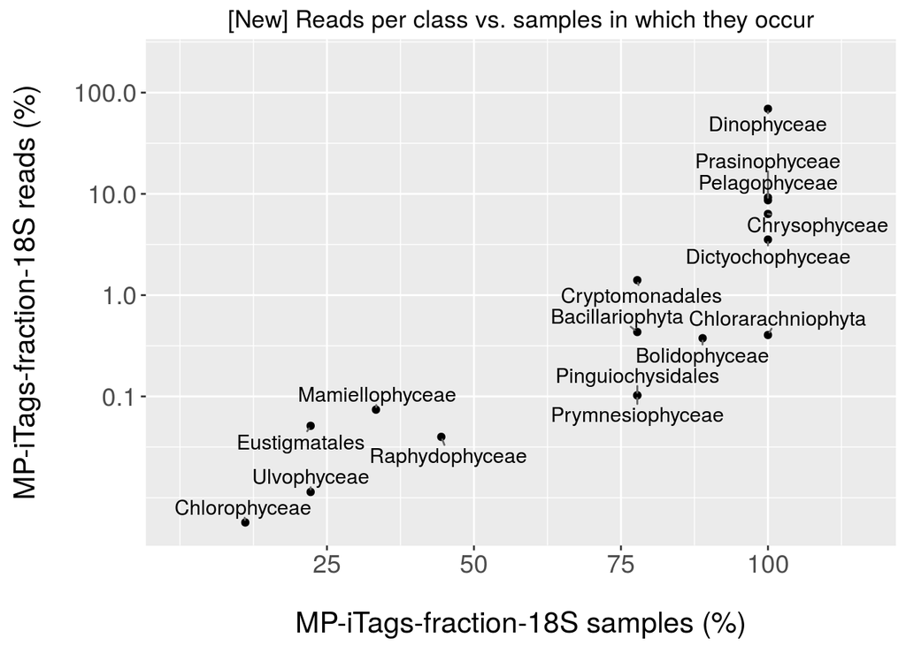

### 1.3.2) Non-normalized data

```
## [1] 22702    17
```

```
##   Row.names st019 st044 st063 st076
## 1     OTU_1  5572   526  1030  2624
## 2    OTU_10  3468   183   376   118
## 3   OTU_100   192     0    42  1497
## 4  OTU_1000    81     0     0     0
## 5 OTU_10000     0     0     0     2
```

```
## [1] 22702    16
```

```
##           st019 st044 st063 st076 st083
## OTU_1      5572   526  1030  2624   167
## OTU_10     3468   183   376   118   205
## OTU_100     192     0    42  1497    24
## OTU_1000     81     0     0     0     0
## OTU_10000     0     0     0     2     0
```

```
## [1] 22702    17
```

```
##       st019 st044 st063 st076 st083
## OTU_1  5572   526  1030  2624   167
## OTU_2  2856   656   544  4199   212
## OTU_3 12685     5   143   792   289
## OTU_4 20486     0     2     2     0
## OTU_5  1124  1353   149  1499   172
```

```
## [1] 6089   17
```

```
##        st019 st044 st063 st076 st083
## OTU_10  3468   183   376   118   205
## OTU_12  1860   381   312  1607    48
## OTU_17  1112   172   698   591   150
## OTU_24   794    99    98   433    53
## OTU_49   645    23   217   547    24
```

```
##        st019 st044 st063 st076 st083
## OTU_10  3468   183   376   118   205
## OTU_12  1860   381   312  1607    48
## OTU_17  1112   172   698   591   150
## OTU_24   794    99    98   433    53
## OTU_49   645    23   217   547    24
```

```
## [1] 5172    9
```

```
## [1] 9
```

```
## [1] 9
```

```
## [1] 9
```

```
## [1] 9
```

```
## [1] 9
```

```
## [1] 9
```

```
## [1] 8
```

```
## [1] 9
```

```
## [1] 9
```

```
## [1] 9
```

```
## [1] 9
```

```
## [1] 9
```

```
## [1] 4
```

```
## [1] 2
```

```
## [1] 6
```

```
## [1] 5
```

```
## [1] 8
```

```
## [1] 1
```

```
##               Group.1      x
## 8         Dinophyceae 161340
## 11      Pelagophyceae  22855
## 13     Prasinophyceae  21920
## 5       Chrysophyceae  11435
## 7    Dictyochophyceae   7639
## 6     Cryptomonadales   2899
## 1     Bacillariophyta   1483
## 2       Bolidophyceae    716
## 3  Chlorarachniophyta    644
## 12  Pinguiochysidales    196
## 14   Prymnesiophyceae    134
## 9       Eustigmatales    124
## 10    Mamiellophyceae    105
## 15     Raphydophyceae     91
## 17        Ulvophyceae     37
## 4       Chlorophyceae     28
## 16   Trebouxiophyceae      2
```

```
##               Group.1    x
## 8         Dinophyceae 5172
## 11      Pelagophyceae  234
## 13     Prasinophyceae  213
## 5       Chrysophyceae  183
## 7    Dictyochophyceae  119
## 1     Bacillariophyta   32
## 3  Chlorarachniophyta   31
## 6     Cryptomonadales   31
## 14   Prymnesiophyceae   22
## 10    Mamiellophyceae   12
## 12  Pinguiochysidales   10
## 2       Bolidophyceae    9
## 4       Chlorophyceae    8
## 17        Ulvophyceae    6
## 9       Eustigmatales    3
## 15     Raphydophyceae    3
## 16   Trebouxiophyceae    1
```

```
##                    reads_per_class OTUs_per_class
## Bacillariophyta               1483             32
## Bolidophyceae                  716              9
## Chlorarachniophyta             644             31
## Chlorophyceae                   28              8
## Chrysophyceae                11435            183
```

```
##                    reads_per_class OTUs_per_class samples_per_class
## Dinophyceae                 161340           5172                 9
## Pelagophyceae                22855            234                 9
## Prasinophyceae               21920            213                 9
## Chrysophyceae                11435            183                 9
## Dictyochophyceae              7639            119                 9
## Cryptomonadales               2899             31                 8
## Bacillariophyta               1483             32                 9
## Bolidophyceae                  716              9                 9
## Chlorarachniophyta             644             31                 9
## Pinguiochysidales              196             10                 9
## Prymnesiophyceae               134             22                 9
## Eustigmatales                  124              3                 2
## Mamiellophyceae                105             12                 4
## Raphydophyceae                  91              3                 8
## Ulvophyceae                     37              6                 5
## Chlorophyceae                   28              8                 6
## Trebouxiophyceae                 2              1                 1
```

```
##   reads_per_class    OTUs_per_class samples_per_class
##           100.000           100.000          1377.778
```

```
##                    reads_per_class OTUs_per_class samples_per_class
## Dinophyceae           6.964878e+01    84.94005584         100.00000
## Pelagophyceae         9.866263e+00     3.84299557         100.00000
## Prasinophyceae        9.462633e+00     3.49811135         100.00000
## Chrysophyceae         4.936369e+00     3.00541961         100.00000
## Dictyochophyceae      3.297676e+00     1.95434390         100.00000
## Cryptomonadales       1.251468e+00     0.50911480          88.88889
## Bacillariophyta       6.401955e-01     0.52553786         100.00000
## Bolidophyceae         3.090897e-01     0.14780752         100.00000
## Chlorarachniophyta    2.780080e-01     0.50911480         100.00000
## Pinguiochysidales     8.461113e-02     0.16423058         100.00000
## Prymnesiophyceae      5.784639e-02     0.36130728         100.00000
## Eustigmatales         5.352949e-02     0.04926917          22.22222
## Mamiellophyceae       4.532739e-02     0.19707670          44.44444
## Raphydophyceae        3.928374e-02     0.04926917          88.88889
## Ulvophyceae           1.597251e-02     0.09853835          55.55556
## Chlorophyceae         1.208730e-02     0.13138446          66.66667
## Trebouxiophyceae      8.633789e-04     0.01642306          11.11111
```

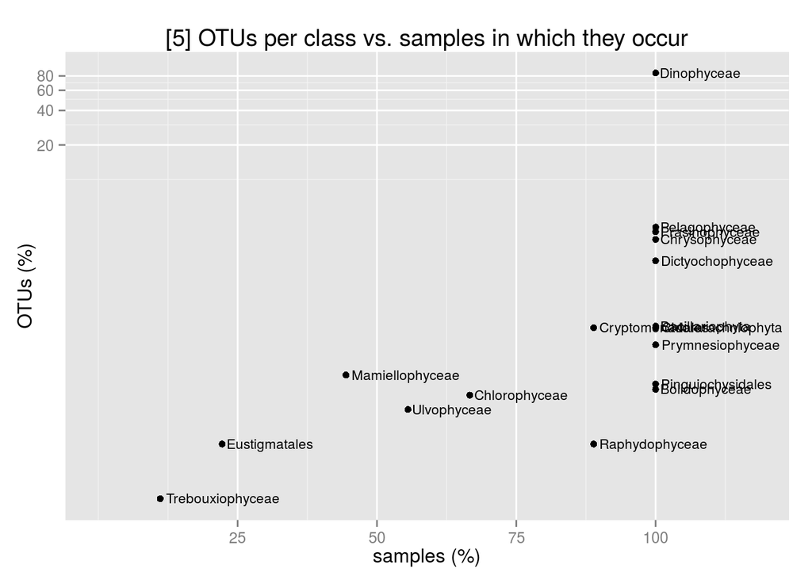

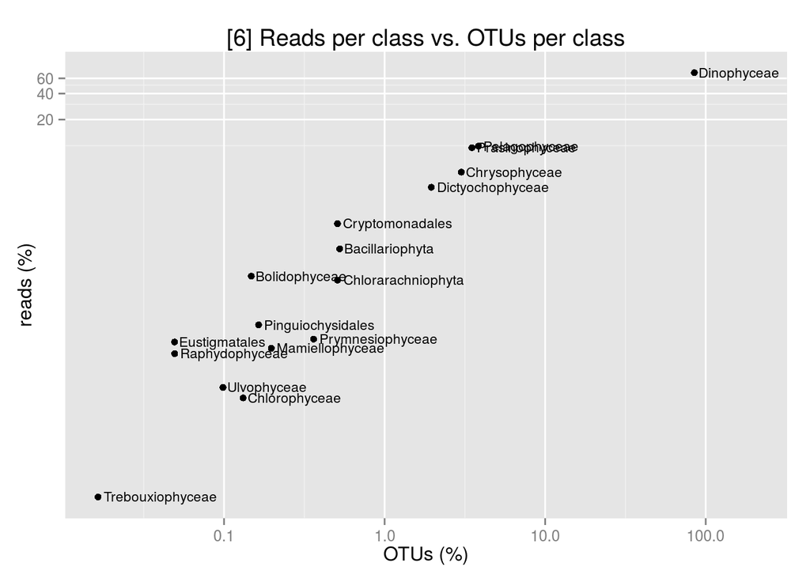

# 2) 16S amplicons

## 2.1) Data overview

Let’s read the dataset and remove the samples containing less than 5836 reads:

```
## [1] 753  17
```

```
##   OTUId st019 st030 st044 st063
## 1 OTU_1 57800  7475  6773 12357
## 2 OTU_2 12358 10015  3654  4666
## 3 OTU_3  3104 15128   553   281
## 4 OTU_4    41 19035  1445    31
## 5 OTU_5   374  4473  2699   112
```

```
## [1] 753  16
```

```
##       st019 st030 st044 st063 st076
## OTU_1 57800  7475  6773 12357  2007
## OTU_2 12358 10015  3654  4666  3703
## OTU_3  3104 15128   553   281   141
## OTU_4    41 19035  1445    31   697
## OTU_5   374  4473  2699   112  2928
```

```
## [1] 753   6
```

```
##                                                                                                        SILVA_taxonomic_classification
## OTU_1   KC002097.1.1314_Bacteria;Cyanobacteria;Cyanobacteria;SubsectionI;FamilyI;Prochlorococcus;unidentified_marine_bacterioplankton
## OTU_2                          EU800388.1.1465_Bacteria;Proteobacteria;Alphaproteobacteria;SAR11_clade;Surface_1;uncultured_bacterium
## OTU_3  EU805005.1.1343_Bacteria;Actinobacteria;Acidimicrobiia;Acidimicrobiales;OM1_clade;Candidatus_Actinomarina;uncultured_bacterium
## OTU_4 KJ590614.1.1421_Bacteria;Proteobacteria;Alphaproteobacteria;Rhodobacterales;Rhodobacteraceae;Sulfitobacter;uncultured_bacterium
## OTU_5     KC000519.1.1314_Bacteria;Cyanobacteria;Cyanobacteria;SubsectionI;FamilyI;Synechococcus;unidentified_marine_bacterioplankton
##                                                                                                Phytoref_taxonomic_classification
## OTU_1   EU803052.1.1425|Bacteria|Cyanobacteria|Cyanobacteria|SubsectionI|FamilyI|Prochlorococcus|uncultured|uncultured+bacterium
## OTU_2                                                                                                                       <NA>
## OTU_3                                                                                                                       <NA>
## OTU_4                                                                                                                       <NA>
## OTU_5 AY663935.1.1244|Bacteria|Cyanobacteria|Cyanobacteria|SubsectionI|FamilyI|Synechococcus|uncultured|uncultured+Synechococcus
##       SILVA_funct_classif Phytoref_funct_classif                class_A
## OTU_1              cyanob                 cyanob          Cyanobacteria
## OTU_2            bacteria                   <NA> heterotrophic_bacteria
## OTU_3            bacteria                   <NA> heterotrophic_bacteria
## OTU_4            bacteria                   <NA> heterotrophic_bacteria
## OTU_5              cyanob                 cyanob          Cyanobacteria
##                      class_B
## OTU_1        Prochlorococcus
## OTU_2 heterotrophic_bacteria
## OTU_3 heterotrophic_bacteria
## OTU_4 heterotrophic_bacteria
## OTU_5          Synechococcus
```

```
## [1] 753  10
```

```
##       st019 st030 st044 st063 st076
## OTU_1 57800  7475  6773 12357  2007
## OTU_2 12358 10015  3654  4666  3703
## OTU_3  3104 15128   553   281   141
## OTU_4    41 19035  1445    31   697
## OTU_5   374  4473  2699   112  2928
```

```
## named numeric(0)
```

```
## [1] 753  10
```

```
## [1] 753   9
```

```
## [1] 753   0
```

Table dimensions and content outline:

```
## [1] 753   9
```

```
##       st019 st044 st063 st076 st083
## OTU_1 57800  6773 12357  2007 26642
## OTU_2 12358  3654  4666  3703  3645
## OTU_3  3104   553   281   141  1908
## OTU_4    41  1445    31   697   104
## OTU_5   374  2699   112  2928   305
```

Minimum number of reads per station:

```r
min(colSums(tb16_tax_occur_min5836))
```

```
## [1] 5836
```

Maximum number of reads per station:

```r
max(colSums(tb16_tax_occur_min5836))
```

```
## [1] 97929
```

Identification of station with higher number of reads:

```r
amplicons_per_sample<-colSums(tb16_tax_occur_min5836)
amplicons_per_sample[which(colSums(tb16_tax_occur_min5836)>97928)]
```

```
## st019
## 97929
```

Overall reads per sample:

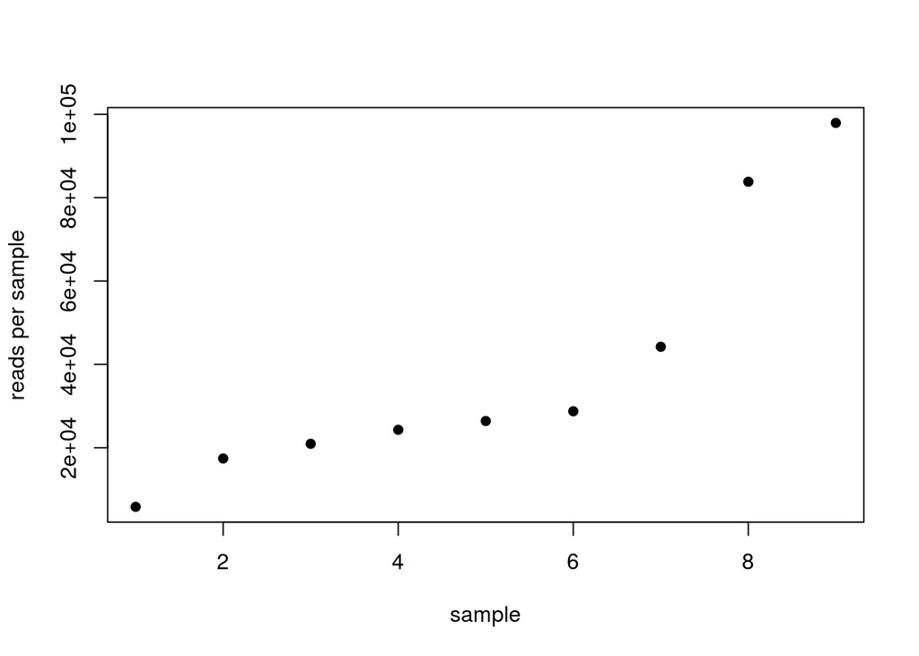

## 2.2) Normalization

Let’s normalize the original dataset by randomly subsampling 5836 reads in each station:

```r
library(vegan)
tb16_tax_occur_min5836_t<-t(tb16_tax_occur_min5836)
tb16_tax_occur_ss5836<-rrarefy(tb16_tax_occur_min5836_t, 5836)
```

The normalized table shows the following dimensions and format:

```
## [1]   9 753
```

```
##       OTU_1 OTU_2 OTU_3 OTU_4 OTU_5
## st019  3375   788   170     2    20
## st044  1516   810   126   330   585
## st063  3469  1312    88     7    35
## st076   661  1231    48   236   970
## st083  3498   503   248    18    40
```

Its content fits with the expected normalization values (5836 reads per station):

```r
rowSums(tb16_tax_occur_ss5836)
```

```
## st019 st044 st063 st076 st083 st092 st101 st120 st141
##  5836  5836  5836  5836  5836  5836  5836  5836  5836
```

Let’s check out how many OTUs don’t appear in the new table:

```r
length(which(colSums(tb16_tax_occur_ss5836)==0))
```

```
## [1] 178
```

```r
tb16_tax_occur_ss5836_no_cero<-tb16_tax_occur_ss5836[,-(which(colSums(tb16_tax_occur_ss5836)==0))]
dim(tb16_tax_occur_ss5836_no_cero)
```

```
## [1]   9 575
```

Datasets summary: dim(tb16_tax) –> 753 16 dim(tb16_tax_occur) –> 753 10 dim(tb16_tax_occur_ss5836_no_cero) –> 9 575

## 2.3) Taxonomic composition analysis

### 2.3.1) Normalized data

#### 2.3.1.1) Absolute values

Let’s add the taxonomic classification to the left OTUs by merging “tb16_tax_occur_ss5836_no_cero” with “tb16_tax”.

```
## [1] 575  16
```

```
##   Row.names st019 st044 st063 st076
## 1     OTU_1  3375  1516  3469   661
## 2    OTU_10    33    29    11    44
## 3   OTU_100     5     1     0     0
## 4   OTU_101     1     7     0     3
## 5   OTU_102     8     7     3     7
```

```
## [1] 575  15
```

```
##         st019 st044 st063 st076 st083
## OTU_1    3375  1516  3469   661  3498
## OTU_10     33    29    11    44    17
## OTU_100     5     1     0     0     3
## OTU_101     1     7     0     3     3
## OTU_102     8     7     3     7     0
```

```
## [1] 575  16
```

```
##                      class_A                class_B OTU_no
## OTU_1          Cyanobacteria        Prochlorococcus      1
## OTU_2 heterotrophic_bacteria heterotrophic_bacteria      2
## OTU_3 heterotrophic_bacteria heterotrophic_bacteria      3
## OTU_4 heterotrophic_bacteria heterotrophic_bacteria      4
## OTU_5          Cyanobacteria          Synechococcus      5
```

```
## [1] 63 16
```

```
## [1] 512  16
```

```
##                                                                  SILVA_taxonomic_classification
## OTU_81  KC001961.1.1257_Bacteria;Cyanobacteria;Chloroplast;unidentified_marine_bacterioplankton
## OTU_124                                                                                    <NA>
## OTU_131                 HQ672001.1.1446_Bacteria;Cyanobacteria;Chloroplast;uncultured_bacterium
## OTU_133   HM565911.2962.4423_Bacteria;Cyanobacteria;Chloroplast;uncultured_prymnesiophyte_C8704
## OTU_137                 EU237456.1.1310_Bacteria;Cyanobacteria;Chloroplast;uncultured_bacterium
##                                                                                                                                                              Phytoref_taxonomic_classification
## OTU_81               774_AY702152|Eukaryota|Hacrobia|Haptophyta|Prymnesiophyceae|Prymnesiophyceae_X|Prymnesiales|Prymnesiales_X|Chrysochromulinaceae|Chrysochromulina|Chrysochromulina_acantha
## OTU_124      432_DQ438491|Eukaryota|Archaeplastida|Chlorophyta|Prasinophyceae|Prasinophyceae_X|Prasino-clade-9|Prasino-clade-9_X|Prasino-clade-9_XX|Prasino-clade-9_XXX|Prasino-clade-9_XXX_sp
## OTU_131                           3719_KC900889|Eukaryota|Hacrobia|Haptophyta|Prymnesiophyceae|Prymnesiophyceae_X|Phaeocystales|Phaeocystales_X|Phaeocystaceae|Phaeocystis|Phaeocystis_globosa
## OTU_133                                                                                                                                                                                   <NA>
## OTU_137 5523_AB847984|Eukaryota|Hacrobia|Haptophyta|Prymnesiophyceae|Prymnesiophyceae_X|Prymnesiophyceae_XX|Prymnesiophyceae_XXX|Braarudosphaeraceae|Braarudosphaera|Braarudosphaera_bigelowii
##         SILVA_funct_classif Phytoref_funct_classif          class_A
## OTU_81              plastid                plastid Prymnesiophyceae
## OTU_124                <NA>                plastid   Prasinophyceae
## OTU_131             plastid                plastid Prymnesiophyceae
## OTU_133             plastid                   <NA>   other_plastids
## OTU_137             plastid                plastid Prymnesiophyceae
##                  class_B OTU_no
## OTU_81  Prymnesiophyceae     81
## OTU_124   Prasinophyceae    124
## OTU_131 Prymnesiophyceae    131
## OTU_133   other_plastids    133
## OTU_137 Prymnesiophyceae    137
```

```
##                                                                                                        SILVA_taxonomic_classification
## OTU_1   KC002097.1.1314_Bacteria;Cyanobacteria;Cyanobacteria;SubsectionI;FamilyI;Prochlorococcus;unidentified_marine_bacterioplankton
## OTU_2                          EU800388.1.1465_Bacteria;Proteobacteria;Alphaproteobacteria;SAR11_clade;Surface_1;uncultured_bacterium
## OTU_3  EU805005.1.1343_Bacteria;Actinobacteria;Acidimicrobiia;Acidimicrobiales;OM1_clade;Candidatus_Actinomarina;uncultured_bacterium
## OTU_4 KJ590614.1.1421_Bacteria;Proteobacteria;Alphaproteobacteria;Rhodobacterales;Rhodobacteraceae;Sulfitobacter;uncultured_bacterium
## OTU_5     KC000519.1.1314_Bacteria;Cyanobacteria;Cyanobacteria;SubsectionI;FamilyI;Synechococcus;unidentified_marine_bacterioplankton
##                                                                                                Phytoref_taxonomic_classification
## OTU_1   EU803052.1.1425|Bacteria|Cyanobacteria|Cyanobacteria|SubsectionI|FamilyI|Prochlorococcus|uncultured|uncultured+bacterium
## OTU_2                                                                                                                       <NA>
## OTU_3                                                                                                                       <NA>
## OTU_4                                                                                                                       <NA>
## OTU_5 AY663935.1.1244|Bacteria|Cyanobacteria|Cyanobacteria|SubsectionI|FamilyI|Synechococcus|uncultured|uncultured+Synechococcus
##       SILVA_funct_classif Phytoref_funct_classif                class_A
## OTU_1              cyanob                 cyanob          Cyanobacteria
## OTU_2            bacteria                   <NA> heterotrophic_bacteria
## OTU_3            bacteria                   <NA> heterotrophic_bacteria
## OTU_4            bacteria                   <NA> heterotrophic_bacteria
## OTU_5              cyanob                 cyanob          Cyanobacteria
##                      class_B OTU_no
## OTU_1        Prochlorococcus      1
## OTU_2 heterotrophic_bacteria      2
## OTU_3 heterotrophic_bacteria      3
## OTU_4 heterotrophic_bacteria      4
## OTU_5          Synechococcus      5
```

```r
class_summary_reads_per_class_16S_protists<-aggregate(rowSums(tb16_protists[1:9]), list(tb16_protists$class_A), sum)
# count the different groups

class_summary_otus_per_class_16S_protists<-aggregate(rowSums(tb16_protists[1:9]), list(tb16_protists$class_A), length)

## READS PER CLASS ##
attach(class_summary_reads_per_class_16S_protists)
class_summary_reads_per_class_16S_protists_order<-class_summary_reads_per_class_16S_protists[order(-x),]
detach(class_summary_reads_per_class_16S_protists)
class_summary_reads_per_class_16S_protists_order
```

```
##               Group.1   x
## 11   Prymnesiophyceae 277
## 8      other_plastids 173
## 6    Dictyochophyceae  49
## 10     Prasinophyceae  45
## 7     Mamiellophyceae   6
## 9       Pelagophyceae   6
## 1     Bacillariophyta   3
## 4       Chrysophyceae   2
## 2       Bolidophyceae   1
## 3  Chlorarachniophyta   1
## 5     Cryptomonadales   1
## 12         Rappemonad   1
```

```r
#fix column names
row.names(class_summary_reads_per_class_16S_protists_order)<-class_summary_reads_per_class_16S_protists_order[,1]
class_summary_reads_per_class_16S_protists_order<-class_summary_reads_per_class_16S_protists_order[c(-1)]
colnames(class_summary_reads_per_class_16S_protists_order)<-c("reads_per_class")


## OTUs PER CLASS ##
attach(class_summary_otus_per_class_16S_protists)
class_summary_otus_per_class_16S_protists_order<-class_summary_otus_per_class_16S_protists[order(-x),]
detach(class_summary_otus_per_class_16S_protists)
class_summary_otus_per_class_16S_protists_order
```

```
##               Group.1  x
## 11   Prymnesiophyceae 22
## 8      other_plastids 19
## 10     Prasinophyceae  8
## 6    Dictyochophyceae  4
## 7     Mamiellophyceae  3
## 1     Bacillariophyta  1
## 2       Bolidophyceae  1
## 3  Chlorarachniophyta  1
## 4       Chrysophyceae  1
## 5     Cryptomonadales  1
## 9       Pelagophyceae  1
## 12         Rappemonad  1
```

```r
row.names(class_summary_otus_per_class_16S_protists_order)<-class_summary_otus_per_class_16S_protists_order[,1]
class_summary_otus_per_class_16S_protists_order<-class_summary_otus_per_class_16S_protists_order[c(-1)]
colnames(class_summary_otus_per_class_16S_protists_order)<-c("OTUs_per_class")
```

```r
class_summary_reads_per_class_16S_bacteria<-aggregate(rowSums(tb16_bacteria[1:9]), list(tb16_bacteria$class_A), sum)
# count the different groups

class_summary_otus_per_class_16S_bacteria<-aggregate(rowSums(tb16_bacteria[1:9]), list(tb16_bacteria$class_A), length)

## READS PER CLASS ##
attach(class_summary_reads_per_class_16S_bacteria)
class_summary_reads_per_class_16S_bacteria_order<-class_summary_reads_per_class_16S_bacteria[order(-x),]
detach(class_summary_reads_per_class_16S_bacteria)
class_summary_reads_per_class_16S_bacteria_order
```

```
##                  Group.1     x
## 2 heterotrophic_bacteria 28845
## 1          Cyanobacteria 23114
```

```r
#fix column names
row.names(class_summary_reads_per_class_16S_bacteria_order)<-class_summary_reads_per_class_16S_bacteria_order[,1]
class_summary_reads_per_class_16S_bacteria_order<-class_summary_reads_per_class_16S_bacteria_order[c(-1)]
colnames(class_summary_reads_per_class_16S_bacteria_order)<-c("reads_per_class")


## OTUs PER CLASS ##
attach(class_summary_otus_per_class_16S_bacteria)
class_summary_otus_per_class_16S_bacteria_order<-class_summary_otus_per_class_16S_bacteria[order(-x),]
detach(class_summary_otus_per_class_16S_bacteria)
class_summary_otus_per_class_16S_bacteria_order
```

```
##                  Group.1   x
## 2 heterotrophic_bacteria 492
## 1          Cyanobacteria  20
```

```r
row.names(class_summary_otus_per_class_16S_bacteria_order)<-class_summary_otus_per_class_16S_bacteria_order[,1]
class_summary_otus_per_class_16S_bacteria_order<-class_summary_otus_per_class_16S_bacteria_order[c(-1)]
colnames(class_summary_otus_per_class_16S_bacteria_order)<-c("OTUs_per_class")
```

```
##         st019 st044 st063 st076 st083
## OTU_133     0     0     0    13     3
## OTU_184     0     4     1     3     0
## OTU_196     0    12     0     0     0
## OTU_197     0     0     0     0     2
## OTU_214     2     2     1     0     1
```

```
##         st019 st044 st063 st076 st083
## OTU_133     0     0     0    13     3
## OTU_184     0     4     1     3     0
## OTU_196     0    12     0     0     0
## OTU_197     0     0     0     0     2
## OTU_214     2     2     1     0     1
```

```
## [1] 19  9
```

```
## [1] 9
```

```
## [1] 9
```

```
## [1] 7
```

```
## [1] 9
```

```
## [1] 2
```

```
## [1] 1
```

```
## [1] 1
```

```
## [1] 1
```

```
## [1] 1
```

```
## [1] 2
```

```
## [1] 1
```

```
## [1] 1
```

```
## [1] 9
```

```
## [1] 9
```

```
##                    reads_per_class OTUs_per_class
## Bacillariophyta                  3              1
## Bolidophyceae                    1              1
## Chlorarachniophyta               1              1
## Chrysophyceae                    2              1
## Cryptomonadales                  1              1
```

```
##                        reads_per_class OTUs_per_class
## Cyanobacteria                    23114             20
## heterotrophic_bacteria           28845            492
## NA                                  NA             NA
## NA.1                                NA             NA
## NA.2                                NA             NA
```

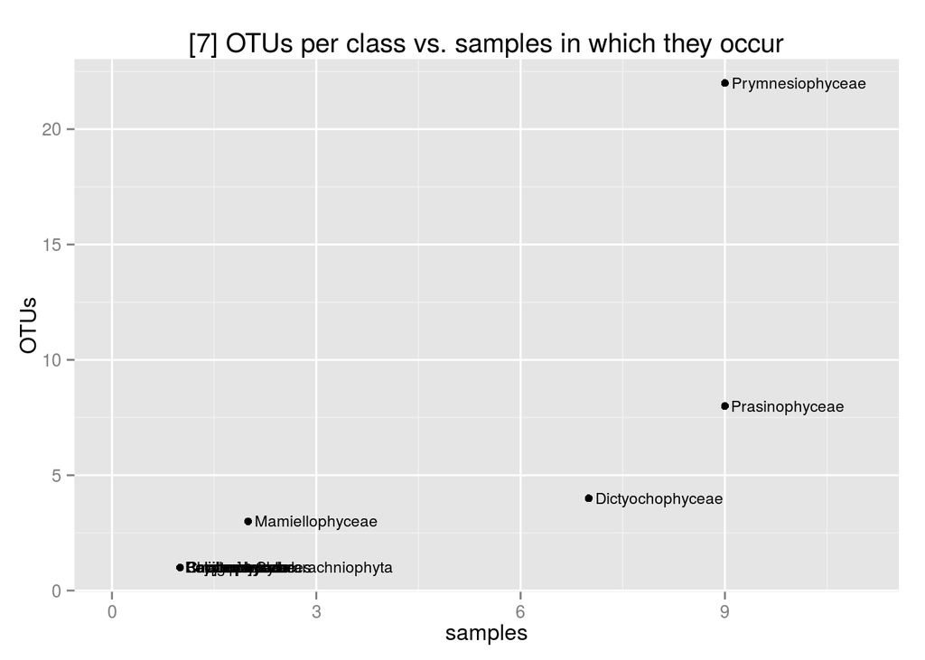

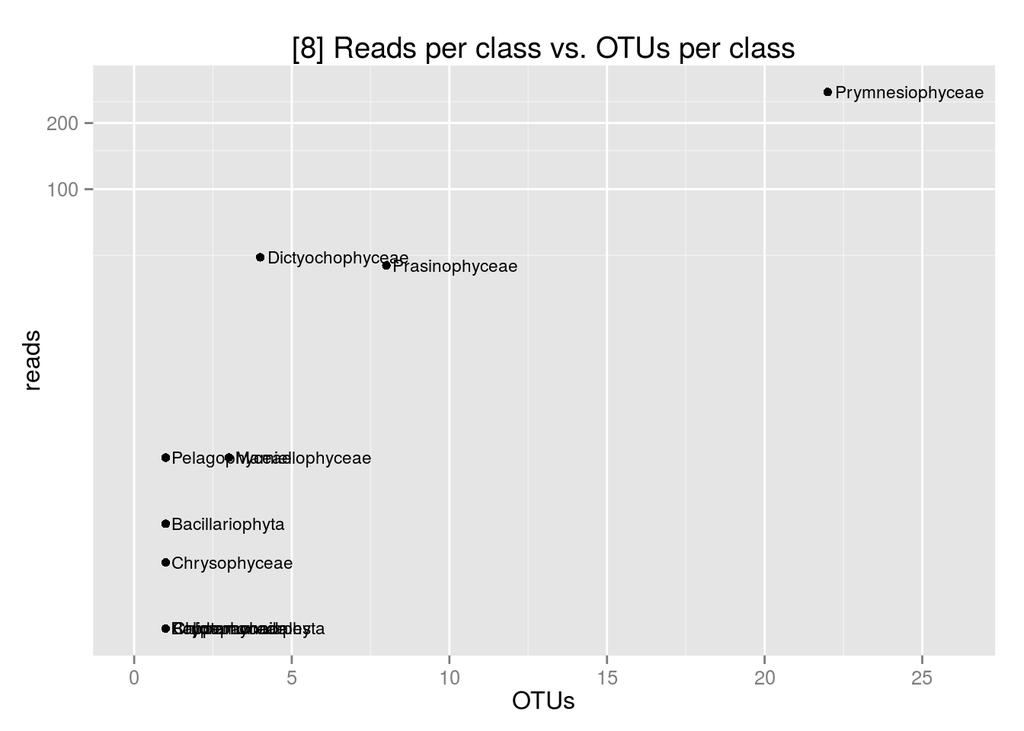

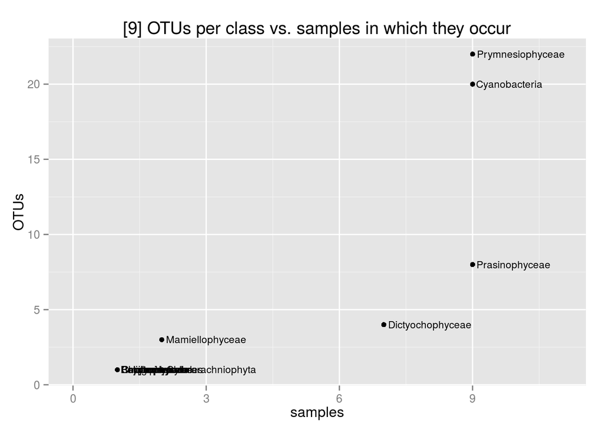

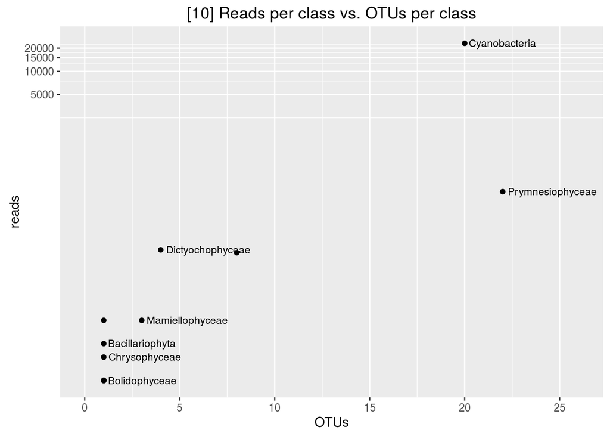

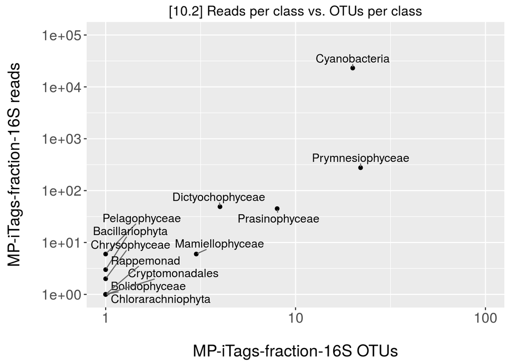